# Lab 7: Movie Recommendation System

Di

3/18/2023

## Background

In this lab I will build a system for recommending movies to viewers. These so-called “Recommender Systems” are incredibly popular and used in applications such as presenting products to shoppers on Amazon, finding new music for listeners on Pandora and Spotify, suggesting pages and users on social media, and identifying potential romantic candidates on dating websites (appropriate for Valentine’s Day!). From 2006 to 2009, Netflix ran a competition to improve their recommendation system by 10%, and eventually gave a $1,000,000 prize to a team that used methods similar to what you will learn in this lab.

## Data

The data I will use comes from MovieLens, a movie recommendation service. It contains 20,000,263 movie ratings from 138,493 users across 26,744 movies.

- `movies.csv` contains the movieIds (a unique identifier), title, and genres of all 27,278 movies.
- `ratings.csv` contains ratings of users on the movies in a tidy format. Each row has a userId, movieId, and rating of that user of that movie. How might you incorporate this data as well?
- `genome-tags.csv` contains descriptions for 1,128 movie properties (atmospheric, thought-provoking, realistic, etc.) called genomes and their corresponding unique identifier tagId number.
- `MovieGenome.csv` contains data about how strongly movies exhibit each genome. The genome score was computed using a machine learning algorithm on user-contributed content including tags, ratings, and textual reviews. The structure is a dense matrix, meaning every movie in the genome has a value for every one of the 1,128 tags in the genome. This has the hilarious impact of Pixar’s “Toy Story” being 1.9% about vampire-human love, 2% neo-nazis, and 1.8% Jane Austen.

## Questions

### 1.Average rating for each genre

```r
library(dplyr)
library(data.table) # load this pacakge
library(readr)
library(ggplot2)
movie_data <- read_csv("C:/Users/62666/Desktop/Spring 2023/DA 350/week10/movies.csv")
rating_data <- read_csv("C:/Users/62666/Desktop/Spring 2023/DA 350/week10/rating.csv")
```

```r
movie_genre <- as.data.frame(movie_data$genres, stringsAsFactors=FALSE)

movie_genre2 <- as.data.frame(tstrsplit(movie_genre[,1], '[|]',
                                        type.convert=TRUE),
                              stringsAsFactors=FALSE) #DataFlair
colnames(movie_genre2) <- c(1:10)
list_genre <- c("Action", "Adventure", "Animation", "Children",
                "Comedy", "Crime","Documentary", "Drama", "Fantasy",
                "Film-Noir", "Horror", "Musical", "Mystery","Romance",
                "Sci-Fi", "Thriller", "War", "Western")
genre_mat1 <- matrix(0,27279,18)
genre_mat1[1,] <- list_genre
colnames(genre_mat1) <- list_genre
for (index in 1:nrow(movie_genre2)) {
  for (col in 1:ncol(movie_genre2)) {
    gen_col = which(genre_mat1[1,] == movie_genre2[index,col]) #Author DataFlair
    genre_mat1[index+1,gen_col] <- 1
  }
}
genre_mat2 <- as.data.frame(genre_mat1[-1,], stringsAsFactors=FALSE) #remove first row, which was the genre list
for (col in 1:ncol(genre_mat2)) {
  genre_mat2[,col] <- as.integer(genre_mat2[,col]) #convert from characters to integers
}
genre_mat2 <- cbind(movie_data[,1] ,genre_mat2)
str(genre_mat2)
```

```
## 'data.frame':    27278 obs. of  19 variables:
##  $ movieId    : num  1 2 3 4 5 6 7 8 9 10 ...
##  $ Action     : int  0 0 0 0 0 1 0 0 1 1 ...
##  $ Adventure  : int  1 1 0 0 0 0 0 1 0 1 ...
##  $ Animation  : int  1 0 0 0 0 0 0 0 0 0 ...
##  $ Children   : int  1 1 0 0 0 0 0 1 0 0 ...
##  $ Comedy     : int  1 0 1 1 1 0 1 0 0 0 ...
##  $ Crime      : int  0 0 0 0 0 1 0 0 0 0 ...
##  $ Documentary: int  0 0 0 0 0 0 0 0 0 0 ...
##  $ Drama      : int  0 0 0 1 0 0 0 0 0 0 ...
##  $ Fantasy    : int  1 1 0 0 0 0 0 0 0 0 ...
##  $ Film-Noir  : int  0 0 0 0 0 0 0 0 0 0 ...
##  $ Horror     : int  0 0 0 0 0 0 0 0 0 0 ...
##  $ Musical    : int  0 0 0 0 0 0 0 0 0 0 ...
##  $ Mystery    : int  0 0 0 0 0 0 0 0 0 0 ...
##  $ Romance    : int  0 0 1 1 0 0 1 0 0 0 ...
##  $ Sci-Fi     : int  0 0 0 0 0 0 0 0 0 0 ...
##  $ Thriller   : int  0 0 0 0 0 1 0 0 0 1 ...
##  $ War        : int  0 0 0 0 0 0 0 0 0 0 ...
##  $ Western    : int  0 0 0 0 0 0 0 0 0 0 ...
```

```r
print(genre_mat2[1:5,1:10])
```

```
##   movieId Action Adventure Animation Children Comedy Crime Documentary Drama
## 1       1      0         1         1        1      1     0           0     0
## 2       2      0         1         0        1      0     0           0     0
## 3       3      0         0         0        0      1     0           0     0
## 4       4      0         0         0        0      1     0           0     1
## 5       5      0         0         0        0      1     0           0     0
##   Fantasy
## 1       1
## 2       1
## 3       0
## 4       0
## 5       0
```

```r
dim(genre_mat2)
```

```
## [1] 27278    19
```

```r
#get average rating for each movie with different genres
meanrating <- rating_data %>%
  group_by(movieId) %>%
  summarise(mean_rating=mean(rating), .groups = 'drop')
#add new column for each movie to genre_mat2
rating_merged <- merge(meanrating, genre_mat2, by="movieId")
```

```r
#for loop to assign corresponding mean rating to each genre of each movie
#if it is one in genre_mat2 dataset, assign the value
for (index in 1:nrow(rating_merged)) {
  for (col in 3:ncol(rating_merged)) {
    if (rating_merged[index, col] == 1) {
      rating_merged[index, col] = rating_merged[index, 2]
    }
  }
}
```

```r
#change 0 to n/a so that will not affect mean value
rating_merged[rating_merged==0] <- NA
mean_genre <- summarize_if(rating_merged[,3:20], is.numeric, mean, na.rm = TRUE)
```

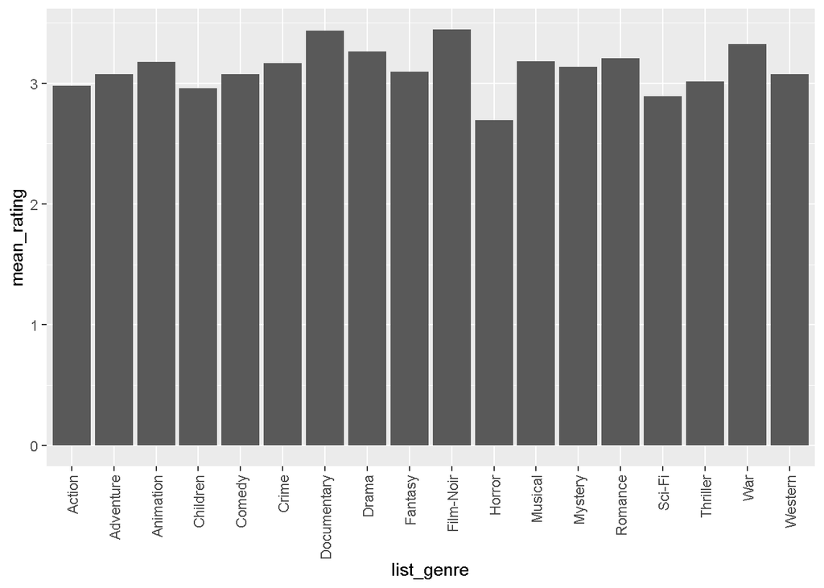

```r
mean_genre2 <- t(mean_genre)
mean_genre2 <- data.frame(list_genre, mean_genre2)
colnames(mean_genre2)[2] <- "mean_rating"
ggplot(mean_genre2, aes(list_genre, y=mean_rating)) +
  geom_bar(stat = "identity") + theme(axis.text.x = element_text(angle=90, vjust=.5, hjust=1))
```

The top three genres are Documentary with mean 3.43, Film-Noir with mean 3.44 and War with mean 3.32.

### 2.Find the **closest movie to “Little Women (1994)”**

```r
genome_tags <- read_csv("C:/Users/62666/Desktop/Spring 2023/DA 350/week10/genome-tags.csv")
MovieGenome <- read_csv("C:/Users/62666/Desktop/Spring 2023/DA 350/week10/MovieGenome.csv")
```

```r
lw <- movie_data %>% filter(title == "Little Women (1994)")
lw$movieId
```

```
## [1] 261
```

```r
#not contain Little Women (1994)
MovieGenome2 <- MovieGenome %>% filter(movieId != 261)
#Little Women (1994) data
MovieGenome3 <- MovieGenome %>% filter(movieId == 261)

#distances <- apply(MovieGenome2[,-1], 1, function(x) sqrt(sum((x - MovieGenome3[,-1])^2)))
#just read the data from the stored data
lw_distances <- read_csv("C:/Users/62666/Desktop/Spring 2023/DA 350/week10/distances.csv")
```

```r
#find the minimum value for distances
which.min(lw_distances$x)
```

```
## [1] 4359
```

```r
MovieGenome2[4359,]
```

| movieId | X1 | X2 | X3 | X4 | X5 | X6 | X7 | X8 | X9 | X10 | X11 | X12 | X13 | X14 | X15 | X16 | X17 | X18 | X19 | X20 | X21 | X22 | X23 | X24 | X25 | X26 | X27 | X28 | X29 | … |
| --- | --- | --- | --- | --- | --- | --- | --- | --- | --- | --- | --- | --- | --- | --- | --- | --- | --- | --- | --- | --- | --- | --- | --- | --- | --- | --- | --- | --- | --- | --- |
| 4921 | 0.02325 | 0.02775 | 0.25125 | 0.2955 | 0.53025 | 0.1275 | 0.1495 | 0.159 | 0.05425 | 0.59625 | 0.019 | 0.03425 | 0.04675 | 0.0075 | 0.00325 | 0.03975 | 0.01925 | 0.163 | 0.0835 | 0.088 | 0.83975 | 0.96075 | 0.04075 | 0.008 | 0.0595 | 0.0815 | 0.163 | 0.19625 | 0.13225 | … |

```r
#movieid = 4921
lw_close <- movie_data %>% filter(movieId == 4921)
lw_close
```

| movieId | title | genres |
| --- | --- | --- |
| 4921 | Little Women (1933) | Drama\|Romance |

```r
#Little Women (1933) is the closest one
```

Little Women (1933) is the closest one with movieId 4921.

### 3.Fit a clustering model for **the first 500 movies** in ‘MovieGenome.csv’

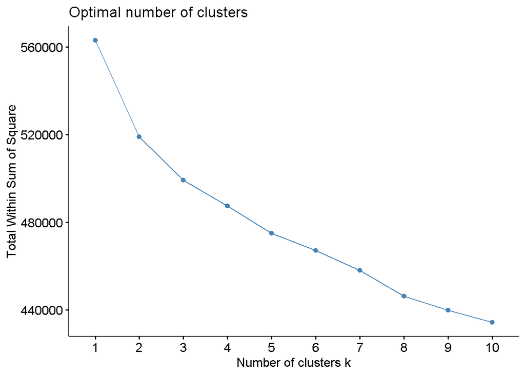

```r
library(cluster)
library(factoextra)
MovieGenome4 <- MovieGenome[1:500,]
# Kmean for first 500 movies
fviz_nbclust(scale(MovieGenome4[,-1]), kmeans, method = "wss") # wss: total within cluster sum of square
```

```r
km.out <- kmeans(scale(MovieGenome[1:500,-1]), 8, nstart = 25)
km.out
```

```
## K-means clustering with 8 clusters of sizes 41, 132, 30, 118, 45, 86, 39, 9
##
## Cluster means:
##            X1           X2          X3         X4            X5          X6
## 1 -0.30810608 -0.282394457  1.48791612  1.7505735  0.9448388392  0.54131523
## 2  0.08011322  0.111248159 -0.26599559 -0.3997226 -0.2543463017 -0.42801135
## 3  0.20401402 -0.025074298  0.04213144 -0.0967767  0.1442523145  0.38067511
## 4 -0.24132538 -0.087578885 -0.04126845  0.0975708  0.1292982938 -0.06161790
## 5 -0.23668927 -0.266139987 -0.25988725  0.0157775  0.0003136655  0.26936597
## 6 -0.04540745 -0.001960987 -0.05803440 -0.2914794 -0.2106598549  0.01161666
## 7  1.03347719  0.563462855 -0.23407111 -0.3652684 -0.3560966344 -0.32499814
## 8 -0.14846378 -0.205572654  0.39191666  1.2202806  0.8045502910  3.30096220
##            X7          X8         X9         X10         X11        X12
## 1  0.22775534  0.20783711 -0.2838695  1.63171864 -0.10594386 -0.1483613
## 2 -0.26676008 -0.47471564 -0.3015200 -0.29996007 -0.07248289 -0.1772679
```

[output cut: 1705 more lines]

The elbow point from the plot seems to be k=8, and the corresponding between_SS / total_SS = 20.8 %, it indicates that the clustering does not explain a large portion of the variance in the data. This could mean that the chosen number of clusters (k) is not optimal or that the dataset has a complex structure that is difficult to capture with k-means clustering.

```r
MovieGenome4$cluster <- km.out$cluster
grouped_data <- MovieGenome4[,-1] %>% group_by(cluster)
cluster_profiles <- grouped_data %>%
  summarise_all(list(mean = mean, median = median, min = min, max = max, sd = sd))
cluster_profiles
```

| cluster | X1_mean | X2_mean | X3_mean | X4_mean | X5_mean | X6_mean | X7_mean | X8_mean | X9_mean | X10_mean | X11_mean | X12_mean | X13_mean | X14_mean | X15_mean | X16_mean | X17_mean | X18_mean | X19_mean | X20_mean | X21_mean | X22_mean | X23_mean | X24_mean | X25_mean | X26_mean | X27_mean | X28_mean | X29_mean | … |
| --- | --- | --- | --- | --- | --- | --- | --- | --- | --- | --- | --- | --- | --- | --- | --- | --- | --- | --- | --- | --- | --- | --- | --- | --- | --- | --- | --- | --- | --- | --- |
| 1 | 0.02546951 | 0.02926220 | 0.29595122 | 0.17905488 | 0.23207317 | 0.11792683 | 0.06568902 | 0.14845732 | 0.05342683 | 0.23193902 | 0.02779268 | 0.03809756 | 0.06783537 | 0.010109756 | 0.004134146 | 0.05143902 | 0.016396341 | 0.2871951 | 0.09604878 | 0.1063780 | 0.4321768 | 0.4102683 | 0.03726829 | 0.01228659 | 0.10344512 | 0.13714024 | 0.15390244 | 0.28505488 | 0.1233415 | … |
| 2 | 0.04580871 | 0.05197348 | 0.03749432 | 0.04107765 | 0.08636932 | 0.04284091 | 0.02912500 | 0.08604735 | 0.05251136 | 0.03156439 | 0.02970833 | 0.03577841 | 0.15543561 | 0.012314394 | 0.003492424 | 0.03639015 | 0.012513258 | 0.2417405 | 0.26917235 | 0.2116439 | 0.3529470 | 0.2588277 | 0.12978977 | 0.03921591 | 0.08958144 | 0.10463258 | 0.09271970 | 0.08192045 | 0.1991098 | … |
| 3 | 0.05230000 | 0.04410833 | 0.08290000 | 0.06051667 | 0.13480000 | 0.10548333 | 0.07987500 | 0.17670833 | 0.10237500 | 0.04285000 | 0.05190833 | 0.06510000 | 0.10190833 | 0.023983333 | 0.003766667 | 0.04379167 | 0.016450000 | 0.2240750 | 0.38217500 | 0.2626667 | 0.4150000 | 0.3795667 | 0.07479167 | 0.01724167 | 0.09731667 | 0.06520000 | 0.10065833 | 0.13853333 | 0.2654750 | … |
| 4 | 0.02896822 | 0.04050212 | 0.07061017 | 0.07298729 | 0.13298305 | 0.07122246 | 0.05387288 | 0.13325000 | 0.06174364 | 0.07058475 | 0.02367585 | 0.02100000 | 0.09544280 | 0.015466102 | 0.005618644 | 0.05826907 | 0.022093220 | 0.1938644 | 0.10353178 | 0.1201292 | 0.3829343 | 0.3218411 | 0.05740466 | 0.02251695 | 0.18056780 | 0.13753178 | 0.13130932 | 0.16877966 | 0.1178517 | … |
| 5 | 0.02921111 | 0.03020000 | 0.03839444 | 0.06773889 | 0.11731111 | 0.09686111 | 0.06806111 | 0.22382778 | 0.10359444 | 0.04450000 | 0.02128889 | 0.02878889 | 0.14345556 | 0.011183333 | 0.003811111 | 0.04113889 | 0.017044444 | 0.3465778 | 0.28660000 | 0.2312167 | 0.4088944 | 0.3531278 | 0.08272222 | 0.02285000 | 0.29522778 | 0.21322222 | 0.11372222 | 0.13563333 | 0.1333889 | … |
| 6 | 0.03923256 | 0.04544186 | 0.06813953 | 0.04802326 | 0.09167733 | 0.07689535 | 0.03947384 | 0.11346802 | 0.05916279 | 0.04886337 | 0.04329070 | 0.08350000 | 0.11644767 | 0.007848837 | 0.003906977 | 0.04332267 | 0.013761628 | 0.1718488 | 0.20516570 | 0.1710640 | 0.3459884 | 0.2919506 | 0.10894186 | 0.03204651 | 0.07801744 | 0.11460465 | 0.18412791 | 0.13727616 | 0.3452238 | … |
| 7 | 0.09575641 | 0.07806410 | 0.04219872 | 0.04328846 | 0.07400641 | 0.05082051 | 0.02400000 | 0.08537821 | 0.06628205 | 0.02292949 | 0.04151282 | 0.10098718 | 0.22372436 | 0.012269231 | 0.003782051 | 0.03160256 | 0.011884615 | 0.2026154 | 0.85564744 | 0.6510641 | 0.3326923 | 0.2410705 | 0.20721795 | 0.10605769 | 0.06841026 | 0.07592308 | 0.05787179 | 0.05523718 | 0.4359487 | … |
| 8 | 0.03383333 | 0.03369444 | 0.13444444 | 0.14502778 | 0.21502778 | 0.33169444 | 0.19333333 | 0.34408333 | 0.25125000 | 0.10558333 | 0.13522222 | 0.20772222 | 0.20325000 | 0.013111111 | 0.007166667 | 0.06113889 | 0.008694444 | 0.3103889 | 0.66730556 | 0.4365000 | 0.4592778 | 0.5151389 | 0.05369444 | 0.01319444 | 0.08263889 | 0.08172222 | 0.08172222 | 0.10591667 | 0.7316111 | … |

The cluster profile describes the attributes of each cluster out of 8 cluster. For example, the cluster1 has the average x1 0.02546951, x2 has mean 0.02926220. So if x1 is smaller than 0.028 and x2 is smaller than 0.03, the cluster1 will have stronger evidence for this observation. However, since the data has around 1200 column variables, it is hard to find the specific mean value for one column variable and then to determine the cluster. The cluster profile data contains the data with min, max, median, sd, mean. So by considering that, there will be an overall view of characteristics of the cluster.

### 4.Fit a clustering model for entire dataset ‘MovieGenome.csv’

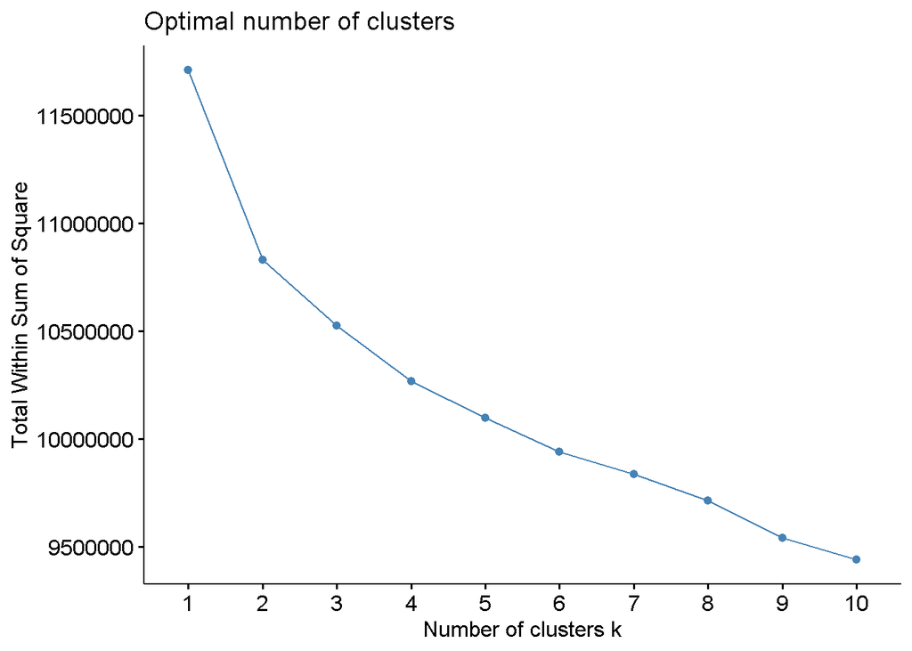

```r
#load the r obeject file for k-mean for entire dataset
#kmean_plot <- fviz_nbclust(scale(MovieGenome[,-1]), kmeans, method = "wss") # wss: total within cluster sum of square
load("C:/Users/62666/Desktop/Spring 2023/DA 350/week10/kmean_plot.RData")
print(kmean_plot)
```

```r
#km.out_all <- kmeans(scale(MovieGenome[,-1]), 8, nstart = 25)
load("C:/Users/62666/Desktop/Spring 2023/DA 350/week10/km.out_all.RData")
km.out_all
```

```
## K-means clustering with 8 clusters of sizes 1355, 2563, 2304, 742, 668, 1252, 693, 804
##
## Cluster means:
##            X1          X2          X3          X4          X5         X6
## 1 -0.24875666 -0.23944766  0.16440356  0.53952002  0.24242261  0.5509900
## 2  0.30104713  0.26488272 -0.31259962 -0.47148546 -0.38045167 -0.5072548
## 3 -0.20321228 -0.17359600 -0.02481942  0.01242084 -0.02736956 -0.1725144
## 4 -0.13606361 -0.14708051 -0.26462441 -0.26255095 -0.32525338 -0.2911778
## 5  0.19783059  0.15742753 -0.10489022 -0.23546268 -0.23995213  0.1681233
## 6 -0.07684034 -0.01539701  0.45053102  0.15074820  0.19378544  0.2046354
## 7 -0.05088742 -0.05765374  0.46809079  0.57884501  0.74012802  0.4876634
## 8  0.16661694  0.13523085  0.01688577  0.26240739  0.44250301  0.5728469
##            X7         X8          X9         X10         X11         X12
## 1  0.57518039  0.7547319  0.20156407  0.34819521 -0.21773247 -0.17360341
## 2 -0.39152580 -0.5749014 -0.10708661 -0.42999353 -0.02445037 -0.06511281
```

[output cut: 1981 more lines]

```r
MovieGenome$cluster <- km.out_all$cluster
grouped_data_all <- MovieGenome[,-1] %>% group_by(cluster)
cluster_profiles_all <- grouped_data_all %>%
  summarise_all(list(mean = mean, median = median, min = min, max = max, sd = sd))
cluster_profiles_all
```

| cluster | X1_mean | X2_mean | X3_mean | X4_mean | X5_mean | X6_mean | X7_mean | X8_mean | X9_mean | X10_mean | X11_mean | X12_mean | X13_mean | X14_mean | X15_mean | X16_mean | X17_mean | X18_mean | X19_mean | X20_mean | X21_mean | X22_mean | X23_mean | X24_mean | X25_mean | X26_mean | X27_mean | X28_mean | X29_mean | … |
| --- | --- | --- | --- | --- | --- | --- | --- | --- | --- | --- | --- | --- | --- | --- | --- | --- | --- | --- | --- | --- | --- | --- | --- | --- | --- | --- | --- | --- | --- | --- |
| 1 | 0.02852085 | 0.03090609 | 0.08730185 | 0.13503524 | 0.17339151 | 0.14526587 | 0.11060646 | 0.25725461 | 0.13987435 | 0.10137804 | 0.02783782 | 0.04521181 | 0.1019046 | 0.01430185 | 0.006841882 | 0.06883782 | 0.03492030 | 0.3343375 | 0.1250539 | 0.1214932 | 0.4003496 | 0.4094240 | 0.04664244 | 0.01248764 | 0.20801162 | 0.24034096 | 0.15187915 | 0.24229244 | 0.1481517 | … |
| 2 | 0.06700878 | 0.06175273 | 0.03537661 | 0.04284354 | 0.08117899 | 0.04134120 | 0.02791797 | 0.08539943 | 0.09659949 | 0.02783272 | 0.04401073 | 0.05804633 | 0.2172610 | 0.01131009 | 0.003758291 | 0.03765168 | 0.01398615 | 0.2414690 | 0.3838190 | 0.2793775 | 0.3274168 | 0.2354294 | 0.15156311 | 0.04748332 | 0.07952799 | 0.10648976 | 0.09944147 | 0.07465363 | 0.2495017 | … |
| 3 | 0.03170909 | 0.03493381 | 0.06670356 | 0.08697005 | 0.13345052 | 0.07421430 | 0.05609158 | 0.14489800 | 0.07098730 | 0.06944607 | 0.02596257 | 0.03502409 | 0.1011549 | 0.01293804 | 0.004877062 | 0.05666591 | 0.02452289 | 0.2509252 | 0.1171750 | 0.1117222 | 0.3455654 | 0.2862367 | 0.05843359 | 0.01861252 | 0.16451096 | 0.15150304 | 0.11841037 | 0.17703798 | 0.1180714 | … |
| 4 | 0.03640970 | 0.03655559 | 0.04059906 | 0.06189589 | 0.08935074 | 0.06256098 | 0.03481435 | 0.11321294 | 0.12488747 | 0.04484131 | 0.04058187 | 0.03970485 | 0.2788706 | 0.00871058 | 0.003895889 | 0.03599158 | 0.01175809 | 0.2299313 | 0.2312581 | 0.1881018 | 0.4000084 | 0.2804363 | 0.11315263 | 0.04391240 | 0.09718969 | 0.11036590 | 0.07683861 | 0.07838646 | 0.1630468 | … |
| 5 | 0.05978331 | 0.05518039 | 0.05798728 | 0.06436602 | 0.10197904 | 0.10766654 | 0.03797867 | 0.13144012 | 0.12578630 | 0.05379004 | 0.14411302 | 0.14485666 | 0.2034491 | 0.01083870 | 0.004613398 | 0.04189034 | 0.01021632 | 0.2849289 | 0.6475820 | 0.4494244 | 0.3946665 | 0.3072885 | 0.26164783 | 0.07946894 | 0.08321707 | 0.08344237 | 0.07040382 | 0.06868151 | 0.4878604 | … |
| 6 | 0.04055551 | 0.04460982 | 0.11844888 | 0.09958387 | 0.16619109 | 0.11125220 | 0.06358127 | 0.14428075 | 0.11915495 | 0.10194569 | 0.08163119 | 0.10406450 | 0.1545114 | 0.01109505 | 0.012273562 | 0.07535543 | 0.01558047 | 0.1833768 | 0.2162969 | 0.1750855 | 0.4042772 | 0.3984455 | 0.08784844 | 0.02375100 | 0.08448383 | 0.11953734 | 0.14841154 | 0.11912819 | 0.3482969 | … |
| 7 | 0.04237229 | 0.04202525 | 0.12036039 | 0.13862121 | 0.24707359 | 0.13904690 | 0.11661436 | 0.26029582 | 0.14049242 | 0.11430844 | 0.02499495 | 0.11432612 | 0.1023380 | 0.07158117 | 0.005025253 | 0.05686797 | 0.02395996 | 0.2826811 | 0.2552587 | 0.1729300 | 0.3965570 | 0.4213644 | 0.05177345 | 0.01309740 | 0.11498918 | 0.12989394 | 0.13222475 | 0.16556457 | 0.2204928 | … |
| 8 | 0.05759826 | 0.05382276 | 0.07124347 | 0.10976586 | 0.20301213 | 0.14741231 | 0.09352332 | 0.27831872 | 0.16760976 | 0.08212966 | 0.02720553 | 0.06973943 | 0.1394335 | 0.01688495 | 0.007882152 | 0.06472450 | 0.01774098 | 0.3285028 | 0.3492335 | 0.2283336 | 0.4467820 | 0.4441200 | 0.06789366 | 0.01626990 | 0.15335728 | 0.12671238 | 0.11779291 | 0.25310914 | 0.1889322 | … |

Problems: Computational complexity: K-means clustering can be computationally time-consuming for large datasets due to the iterative nature of the algorithm. Each iteration requires calculating the distances between all data points and cluster centroids Solution: One approach to address this issue is to use approximate algorithms like Mini-Batch K-Means, which is a variation of the standard k-means algorithm.

Convergence to local optima: K-means is sensitive to the initial position of cluster centroids, and it can converge to local optima rather than the global optimum solution. This issue can be particularly problematic for large or high-dimensional datasets. Solution: Run the k-means algorithm multiple times with different initializations of cluster centroids and choose the best result based on the lowest within-cluster sum of squares (WSS). Another approach is to use advanced initialization techniques like K-means++ or scalable K-means++, which improve the initialization of cluster centroids and reduce the likelihood of converging to local optima.

Scalability: K-means can be inefficient for high-dimensional datasets due to the “curse of dimensionality.” The performance of distance-based methods like k-means tends to degrade as the number of dimensions increases. Solution: Apply dimensionality reduction techniques, such as Principal Component Analysis (PCA) or t-distributed Stochastic Neighbor Embedding (t-SNE), to reduce the number of dimensions while preserving the structure of the data. This can improve the performance of k-means clustering and make it more scalable for high-dimensional datasets.

### 5.**Find the underlying clusters of the users** by ratings of 5 movies

```r
movie199 <- rating_data %>% filter(movieId == 199)
colnames(movie199)[3] = "movie199"
movie199 <- movie199[,-c(4,2)]

movie499 <- rating_data %>% filter(movieId == 499)
colnames(movie499)[3] = "movie499"
movie499 <- movie499[,-c(4,2)]

movie999 <- rating_data %>% filter(movieId == 999)
colnames(movie999)[3] = "movie999"
movie999 <- movie999[,-c(4,2)]

movie1414 <- rating_data %>% filter(movieId == 1414)
colnames(movie1414)[3] = "movie1414"
movie1414 <- movie1414[,-c(4,2)]

movie1919 <- rating_data %>% filter(movieId == 1919)
colnames(movie1919)[3] = "movie1919"
movie1919 <- movie1919[,-c(4,2)]
#the dataset has six columns and the first is userid
five_movie <- merge(movie199, movie499, by='userId', all=TRUE)
five_movie <- merge(five_movie, movie999, by='userId', all=TRUE)
five_movie <- merge(five_movie, movie1414, by='userId', all=TRUE)
five_movie <- merge(five_movie, movie1919, by='userId', all=TRUE)
five_movie_copy <- five_movie
```

```r
#mean rating for movieId 199 = 3.783641
meanrating %>% filter(movieId==199)
```

| movieId | mean_rating |
| --- | --- |
| 199 | 3.783641 |

```r
#mean rating for movieId 499 = 2.763614
meanrating %>% filter(movieId==499)
```

| movieId | mean_rating |
| --- | --- |
| 499 | 2.763614 |

```r
#mean rating for movieId 999 = 3.288988
meanrating %>% filter(movieId==999)
```

| movieId | mean_rating |
| --- | --- |
| 999 | 3.288988 |

```r
#mean rating for movieId 1414 = 3.43568
meanrating %>% filter(movieId==1414)
```

| movieId | mean_rating |
| --- | --- |
| 1414 | 3.43568 |

```r
#mean rating for movieId 1919 = 3.127304
meanrating %>% filter(movieId==1919)
```

| movieId | mean_rating |
| --- | --- |
| 1919 | 3.127304 |

```r
average_five <- c(3.783641, 2.763614, 3.288988, 3.43568, 3.127304)
for(i in 1:ncol(five_movie[,-1])) {                                   # Replace NA in all columns
  five_movie[ , i+1][is.na(five_movie[ , i+1])] <- average_five[i]
}
```

Since there are most of missing data, so the mean rating for each movie is filled to replace missing data.

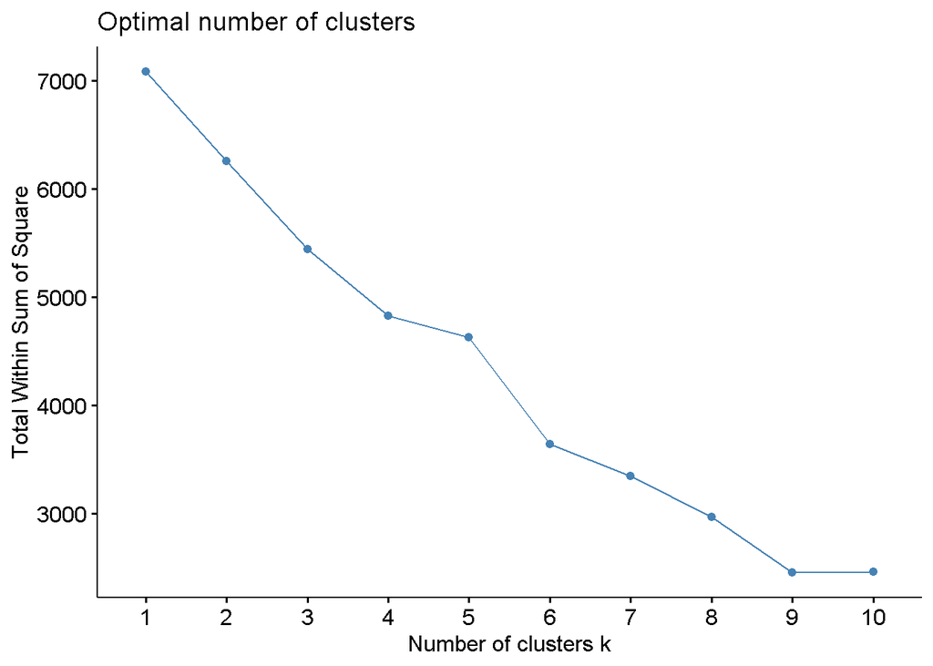

```r
#drop the first column userid for kmeans
fviz_nbclust(five_movie[,-1], kmeans, method = "wss") # wss: total within cluster sum of square
```

```r
km.out2 <- kmeans(scale(five_movie[,-1]), 9, nstart = 20)
km.out2
```

```
## K-means clustering with 9 clusters of sizes 439, 69, 506, 182, 288, 210, 235, 4624, 127
##
## Cluster means:
##       movie199     movie499    movie999   movie1414    movie1919
## 1  2.285206633  0.017547416  0.01785294  0.05260978  0.017512342
## 2 -0.072494277  6.126953044  0.13110015  0.18443290  0.170885106
## 3 -0.012561666  0.010122735 -2.35640633 -0.01035485  0.008591892
## 4 -0.156881038  0.022793283 -0.02185242 -0.05180938 -4.137502140
## 5  0.005678785  0.011463281  0.04249804  0.01775267  2.921177282
## 6  0.051558363 -0.001207173  0.06232921  3.13863153  0.088198606
## 7  0.022935008  0.007747574 -0.07159302 -3.51028662 -0.089380697
## 8 -0.210239961  0.036724194  0.25816805  0.03206735 -0.021793452
## 9 -0.070849983 -4.837912048 -0.17982569 -0.06882020 -0.069641539
##
## Clustering vector:
```

[output cut: 191 more lines]

```r
five_movie$cluster <- km.out2$cluster
grouped_data2 <- five_movie[,-1] %>% group_by(cluster)
cluster_profiles2 <- grouped_data2 %>%
  summarise_all(list(mean = mean, median = median, min = min, max = max, sd = sd))
cluster_profiles2
```

| cluster | movie199_mean | movie499_mean | movie999_mean | movie1414_mean | movie1919_mean | movie199_median | movie499_median | movie999_median | movie1414_median | movie1919_median | movie199_min | movie499_min | movie999_min | movie1414_min | movie1919_min | movie199_max | movie499_max | movie999_max | movie1414_max | movie1919_max | movie199_sd | movie499_sd | movie999_sd | movie1414_sd | movie1919_sd |
| --- | --- | --- | --- | --- | --- | --- | --- | --- | --- | --- | --- | --- | --- | --- | --- | --- | --- | --- | --- | --- | --- | --- | --- | --- | --- |
| 1 | 4.919134 | 2.767383 | 3.300169 | 3.461342 | 3.133785 | 5.000000 | 2.763614 | 3.288988 | 3.43568 | 3.127304 | 4.500000 | 2.763614 | 2.0 | 2.5 | 2.5 | 5.0 | 3.0 | 5.0 | 4.0 | 4.000000 | 0.1843121 | 0.02964445 | 0.2304939 | 0.1601386 | 0.09310116 |
| 2 | 3.747619 | 4.079710 | 3.371092 | 3.525644 | 3.190543 | 3.783641 | 4.000000 | 3.288988 | 3.43568 | 3.127304 | 1.000000 | 3.500000 | 2.0 | 3.0 | 3.0 | 5.0 | 5.0 | 5.0 | 5.0 | 5.000000 | 0.4618899 | 0.41677322 | 0.3739262 | 0.3195717 | 0.28522566 |
| 3 | 3.777399 | 2.765788 | 1.813241 | 3.430629 | 3.130484 | 3.783641 | 2.763614 | 2.000000 | 3.43568 | 3.127304 | 3.000000 | 2.500000 | 0.5 | 2.0 | 2.5 | 4.5 | 3.0 | 2.5 | 4.0 | 4.000000 | 0.1206396 | 0.03596234 | 0.5016829 | 0.1965096 | 0.07341471 |
| 4 | 3.705689 | 2.768510 | 3.275302 | 3.410408 | 1.596154 | 3.783641 | 2.763614 | 3.288988 | 3.43568 | 2.000000 | 1.000000 | 2.000000 | 1.0 | 1.0 | 0.5 | 5.0 | 3.5 | 4.0 | 4.5 | 2.000000 | 0.4767895 | 0.09011631 | 0.2661237 | 0.2729434 | 0.50722573 |
| 5 | 3.786463 | 2.766076 | 3.315603 | 3.444339 | 4.208333 | 3.783641 | 2.763614 | 3.288988 | 3.43568 | 4.000000 | 3.000000 | 2.763614 | 2.0 | 2.0 | 4.0 | 5.0 | 3.0 | 5.0 | 5.0 | 5.000000 | 0.1141674 | 0.02404184 | 0.2217525 | 0.2241591 | 0.39816653 |
| 6 | 3.809260 | 2.763355 | 3.328023 | 4.966667 | 3.159943 | 3.783641 | 2.763614 | 3.288988 | 5.00000 | 3.127304 | 3.783641 | 2.000000 | 2.0 | 4.5 | 3.0 | 5.0 | 3.0 | 5.0 | 5.0 | 4.000000 | 0.1495648 | 0.05993327 | 0.3294717 | 0.1250199 | 0.16780705 |
| 7 | 3.795037 | 2.765278 | 3.244151 | 1.723404 | 3.094227 | 3.783641 | 2.763614 | 3.288988 | 2.00000 | 3.127304 | 2.500000 | 2.000000 | 0.5 | 0.5 | 2.0 | 5.0 | 3.0 | 5.0 | 2.5 | 3.127304 | 0.2474878 | 0.06495290 | 0.4178778 | 0.5064595 | 0.18269011 |
| 8 | 3.679175 | 2.771503 | 3.450671 | 3.451322 | 3.119239 | 3.783641 | 2.763614 | 3.288988 | 3.43568 | 3.127304 | 0.500000 | 2.500000 | 3.0 | 3.0 | 2.5 | 4.0 | 3.0 | 5.0 | 4.0 | 3.500000 | 0.4453408 | 0.04442928 | 0.4905704 | 0.2339943 | 0.07185508 |
| 9 | 3.748436 | 1.724409 | 3.176369 | 3.402110 | 3.101532 | 3.783641 | 2.000000 | 3.288988 | 3.43568 | 3.127304 | 2.000000 | 0.500000 | 1.0 | 1.0 | 1.0 | 5.0 | 2.0 | 4.0 | 5.0 | 4.000000 | 0.3273580 | 0.45298245 | 0.4932156 | 0.4336697 | 0.26105595 |

### 6.**Find the underlying clusters of the friend** by ratings of first 4 movies

```r
rating_friend <- scale(c(3.8, 4, 4.4, 1.9))
movie_distances <- apply((km.out2$centers)[,-5], 1, function(x) sqrt(sum((x - rating_friend)^2)))
which.min(movie_distances)
```

```
## 8
## 8
```